# Linear Models Project: Student Performance Analysis

# 5 Interpretation and Inference

## 5.1 Model Equation

The final model includes 10 main predictors plus one interaction term between `study_hrs` and `sleep_qual`. The regression equation is:

$$\begin{aligned}
\hat{y} = &\ \beta_0 + \beta_1 \cdot \text{attend\_pct} + \beta_2 \cdot \text{study\_hrs} + \beta_3 \cdot \text{sleep\_hrs} \\
&+ \beta_4 \cdot \mathbb{1}_{\text{trav\_time = 15-30 Min}} + \beta_5 \cdot \mathbb{1}_{\text{trav\_time = 30-60 Min}} + \beta_6 \cdot \mathbb{1}_{\text{trav\_time > 60 Min}} \\
&+ \beta_7 \cdot \mathbb{1}_{\text{sleep\_qual = Average}} + \beta_8 \cdot \mathbb{1}_{\text{sleep\_qual = Good}} \\
&+ \sum_{k=1}^{5} \gamma_k \cdot \mathbb{1}_{\text{parent\_educ = level } k} \\
&+ \delta_1 \cdot \mathbb{1}_{\text{extra\_act = Yes}} + \delta_2 \cdot \mathbb{1}_{\text{web\_access = Yes}} + \delta_3 \cdot \mathbb{1}_{\text{school\_type = Private}} \\
&+ \sum_{m=1}^{5} \phi_m \cdot \mathbb{1}_{\text{study\_method = method } m} \\
&+ \lambda_1 \cdot (\text{study\_hrs} \times \mathbb{1}_{\text{sleep\_qual = Average}}) \\
&+ \lambda_2 \cdot (\text{study\_hrs} \times \mathbb{1}_{\text{sleep\_qual = Good}})
\end{aligned}$$

where $\mathbb{1}_{\{\cdot\}}$ denotes indicator (dummy) variables.

## 5.2 Reference Categories

For each categorical variable, one level is absorbed into the intercept as the **reference category**. All coefficients for that variable represent differences relative to this reference.

```r
reference_table <- data.frame(
  Variable = c("school_type", "parent_educ", "sleep_qual", "trav_time",
               "extra_act", "web_access", "study_method"),
  Reference = c("Public", "No Formal", "Poor", "<15 Min", "No", "No", "Online Videos"),
  Other_Levels = c("Private",
                   "High School, Graduate, Post Grad 1, Post Grad 2, PhD",
                   "Average, Good",
                   "15-30 Min, 30-60 Min, >60 Min",
                   "Yes",
                   "Yes",
                   "Coaching, Notes, Textbook, Group Study, Mixed"),
  Interpretation = c("Coefficients show Private vs Public difference",
                     "Coefficients show improvement over No Formal Education",
                     "Coefficients show improvement over Poor sleep",
                     "Coefficients show effect of longer commute vs shortest",
                     "Coefficient shows effect of participation",
                     "Coefficient shows effect of having internet",
                     "Coefficients show difference from Online Videos")
)

reference_table |>
  kable(col.names = c("Variable", "Reference Category", "Other Levels", "Interpretation")) |>
  kable_styling(bootstrap_options = c("striped", "hover"), font_size = 11)
```

Table 10: Reference categories for categorical variables (absorbed in intercept)

| Variable | Reference Category | Other Levels | Interpretation |
| --- | --- | --- | --- |
| school_type | Public | Private | Coefficients show Private vs Public difference |
| parent_educ | No Formal | High School, Graduate, Post Grad 1, Post Grad 2, PhD | Coefficients show improvement over No Formal Education |
| sleep_qual | Poor | Average, Good | Coefficients show improvement over Poor sleep |
| trav_time | <15 Min | 15-30 Min, 30-60 Min, >60 Min | Coefficients show effect of longer commute vs shortest |
| extra_act | No | Yes | Coefficient shows effect of participation |
| web_access | No | Yes | Coefficient shows effect of having internet |
| study_method | Online Videos | Coaching, Notes, Textbook, Group Study, Mixed | Coefficients show difference from Online Videos |

## 5.3 Coefficient Table with Confidence Intervals

```r
# Extract model parameters
params <- model_parameters(final_model, ci = 0.95, ci_method = "residual")

# Create formatted table
params |>
  as.data.frame() |>
  mutate(
    Significance = case_when(
      p < 0.001 ~ "***",
      p < 0.01 ~ "**",
      p < 0.05 ~ "*",
      p < 0.10 ~ ".",
      TRUE ~ ""
    ),
    CI = paste0("[", round(CI_low, 2), ", ", round(CI_high, 2), "]")
  ) |>
  select(Parameter, Coefficient, SE, CI, t, p, Significance) |>
  kable(digits = c(0, 3, 3, 0, 2, 4, 0),
        col.names = c("Term", "Estimate (β)", "Std. Error", "95% CI", "t-value", "p-value", ""),
        align = "lrrrrrr") |>
  kable_styling(bootstrap_options = c("striped", "hover"), font_size = 10) |>
  footnote(general = "Signif. codes: *** p<0.001, ** p<0.01, * p<0.05, . p<0.10",
           general_title = "")
```

Table 11: Final model coefficients with standard errors and 95% confidence intervals

| Term | Estimate (β) | Std. Error | 95% CI | t-value | p-value |  |
| --- | --- | --- | --- | --- | --- | --- |
| (Intercept) | -6.565 | 1.479 | [-9.46, -3.67] | -4.44 | 0.0000 | *** |
| attend_pct | 0.454 | 0.016 | [0.42, 0.48] | 29.25 | 0.0000 | *** |
| study_hrs | 1.164 | 0.094 | [0.98, 1.35] | 12.35 | 0.0000 | *** |
| sleep_hrs | 2.268 | 0.183 | [1.91, 2.63] | 12.37 | 0.0000 | *** |
| trav_time15-30 Min | -0.134 | 0.388 | [-0.89, 0.63] | -0.35 | 0.7292 |  |
| trav_time30-60 Min | -1.773 | 0.396 | [-2.55, -1] | -4.48 | 0.0000 | *** |
| trav_time>60 Min | -3.745 | 0.408 | [-4.55, -2.95] | -9.18 | 0.0000 | *** |
| sleep_qualAverage | -4.725 | 1.134 | [-6.95, -2.5] | -4.17 | 0.0000 | *** |
| sleep_qualGood | -10.819 | 1.147 | [-13.07, -8.57] | -9.43 | 0.0000 | *** |
| parent_educHigh School | 0.719 | 0.460 | [-0.18, 1.62] | 1.56 | 0.1181 |  |
| parent_educGraduate | 1.323 | 0.471 | [0.4, 2.25] | 2.81 | 0.0050 | ** |
| parent_educPost Grad 1 | 1.800 | 0.473 | [0.87, 2.73] | 3.81 | 0.0001 | *** |
| parent_educPost Grad 2 | 2.444 | 0.481 | [1.5, 3.39] | 5.09 | 0.0000 | *** |
| parent_educPhD | 1.888 | 0.456 | [0.99, 2.78] | 4.14 | 0.0000 | *** |
| extra_actYes | 0.822 | 0.285 | [0.26, 1.38] | 2.89 | 0.0039 | ** |
| web_accessYes | 1.106 | 0.357 | [0.41, 1.81] | 3.10 | 0.0019 | ** |
| school_typePrivate | 2.126 | 0.281 | [1.57, 2.68] | 7.56 | 0.0000 | *** |
| study_methodCoaching | 0.649 | 0.417 | [-0.17, 1.47] | 1.56 | 0.1196 |  |
| study_methodNotes | -1.922 | 0.471 | [-2.84, -1] | -4.08 | 0.0000 | *** |
| study_methodTextbook | -0.806 | 0.468 | [-1.72, 0.11] | -1.72 | 0.0855 | . |
| study_methodGroup Study | -1.448 | 0.447 | [-2.33, -0.57] | -3.24 | 0.0012 | ** |
| study_methodMixed | 1.852 | 0.420 | [1.03, 2.67] | 4.41 | 0.0000 | *** |
| study_hrs:sleep_qualAverage | 1.027 | 0.125 | [0.78, 1.27] | 8.23 | 0.0000 | *** |
| study_hrs:sleep_qualGood | 1.886 | 0.123 | [1.64, 2.13] | 15.32 | 0.0000 | *** |

Signif. codes: *** p<0.001, ** p<0.01, * p<0.05, . p<0.10

## 5.4 Interpretation of Key Effects

We interpret the six most important coefficients, focusing on practical significance (effect magnitude in meaningful units) rather than relying solely on p-values.

### 5.4.1 1. Attendance Rate (`attend_pct`)

**Estimate**: $\hat{\beta} = 0.454$ points per percentage point (95% CI: [0.424, 0.485])

**Interpretation**: Each additional percentage point of class attendance is associated with approximately **0.45 points** higher exam score, holding all other variables constant.

**Practical significance**: Consider a meaningful increment of 20 percentage points (e.g., improving from 70% to 90% attendance):
$$\Delta \hat{y} = 0.454 \times 20 = 9.1 \text{ points}$$
This is both statistically significant ($p < 0.001$) and practically meaningful.

### 5.4.2 2. Study Hours (`study_hrs`) — Conditional on Sleep Quality

Due to the interaction term, the effect of study hours depends on sleep quality. The main effect coefficient represents the slope **for students with Poor sleep quality** (the reference category).

```r
# Extract coefficients
beta_study <- coef(final_model)["study_hrs"]
beta_int_avg <- coef(final_model)["study_hrs:sleep_qualAverage"]
beta_int_good <- coef(final_model)["study_hrs:sleep_qualGood"]

# Calculate total effects
effect_poor <- beta_study
effect_avg <- beta_study + beta_int_avg
effect_good <- beta_study + beta_int_good

# Create table
study_effects <- data.frame(
  Sleep_Quality = c("Poor (reference)", "Average", "Good"),
  Main_Effect = c(round(beta_study, 3), round(beta_study, 3), round(beta_study, 3)),
  Interaction = c("—", round(beta_int_avg, 3), round(beta_int_good, 3)),
  Total_Effect = c(round(effect_poor, 3), round(effect_avg, 3), round(effect_good, 3)),
  Interpretation = c(
    paste0("Each +1h → +", round(effect_poor, 2), " points"),
    paste0("Each +1h → +", round(effect_avg, 2), " points"),
    paste0("Each +1h → +", round(effect_good, 2), " points")
  )
)

study_effects |>
  kable(col.names = c("Sleep Quality", "Main Effect (β₂)", "Interaction (λ)",
                      "Total Effect", "Interpretation"),
        align = "lccrl") |>
  kable_styling(bootstrap_options = c("striped", "hover"))
```

Table 12: Marginal effect of one additional hour of study, by sleep quality

|  | Sleep Quality | Main Effect (β₂) | Interaction (λ) | Total Effect | Interpretation |
| --- | --- | --- | --- | --- | --- |
|  | Poor (reference) | 1.164 | — | 1.164 | Each +1h → +1.16 points |
| study_hrs:sleep_qualAverage | Average | 1.164 | 1.027 | 2.191 | Each +1h → +2.19 points |
| study_hrs:sleep_qualGood | Good | 1.164 | 1.886 | 3.051 | Each +1h → +3.05 points |

**Key insight**: The benefit of studying is nearly **three times greater** for well-rested students (3.05 points/hour) compared to sleep-deprived students (1.16 points/hour). This interaction is highly significant and has important practical implications: **optimizing sleep may be as important as optimizing study time**.

### 5.4.3 3. Commute Time (`trav_time`)

**Estimates** (relative to <15 Min): - 15-30 Min: $\hat{\beta} = -0.13$ points (not significant, $p = 0.73$) - 30-60 Min: $\hat{\beta} = -1.77$ points ($p < 0.001$) - >60 Min: $\hat{\beta} = -3.75$ points ($p < 0.001$)

**Interpretation**: Students with long commutes (>60 minutes) score approximately **3.75 points lower** than students with short commutes (<15 minutes), holding all else constant. The effect shows that longer commutes are associated with lower scores.

**Practical significance**: The 3.75-point penalty for very long commutes is meaningful but smaller than the effects of attendance and study habits.

### 5.4.4 4. School Type (`school_type`)

**Estimate**: Private vs Public: $\hat{\beta} = 2.13$ points (95% CI: [1.57, 2.68], $p < 0.001$)

**Interpretation**: Students in private schools score **2.1 points higher** than students in public schools.

**Discussion**: This is statistically significant. The true school type effect may reflect unmeasured factors (teacher quality, peer effects, resources) not captured by our predictors.

### 5.4.5 5. Parental Education (`parent_educ`)

**Estimates** (relative to No Formal Education): - High School: +0.72 points (not significant) - Graduate: +1.32 points ($p = 0.005$) - Post Grad 1: +1.80 points ($p < 0.001$) - Post Grad 2: +2.44 points ($p < 0.001$) - PhD: +1.89 points ($p < 0.001$)

**Interpretation**: Students with more educated parents tend to score higher. The maximum difference is approximately **2.4 points** between students whose parents have Post Graduate education and those with no formal parental education.

**Note**: The non-monotonic pattern (Post Grad 2 > PhD) may reflect sampling variation or different distributions of other characteristics across these groups.

### 5.4.6 6. Sleep Duration (`sleep_hrs`)

**Estimate**: $\hat{\beta} = 2.27$ points per hour (95% CI: [1.91, 2.63], $p < 0.001$)

**Interpretation**: Each additional hour of sleep is associated with **2.27 points** higher exam score.

**Practical significance**: A student who increases sleep from 6 to 8 hours (a 2-hour increase) would be expected to score approximately **4.5 points higher**. This reinforces the importance of adequate rest for academic performance.

## 5.5 Interaction Effect Visualization

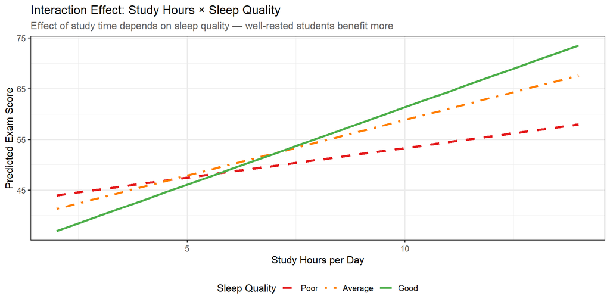

Figure 11: Predicted exam scores by study hours and sleep quality. Lines show model predictions holding other variables at reference levels (Public school, No Formal parent education, <15 Min commute, No extracurricular activities, No internet, Online Videos study method) and median values for continuous predictors. Steeper slopes indicate greater benefit from additional study time.

```r
# Create prediction grid
study_vals <- seq(2, 14, by = 0.5)  # Realistic range of study hours
sleep_levels <- levels(data_train$sleep_qual)

# Build prediction data frame
grid_interact <- expand.grid(
  study_hrs = study_vals,
  sleep_qual = factor(sleep_levels, levels = sleep_levels)
) |>
  mutate(
    attend_pct = median(data_train$attend_pct),
    sleep_hrs = median(data_train$sleep_hrs),
    school_type = factor("Public", levels = levels(data_train$school_type)),
    parent_educ = factor("No Formal", levels = levels(data_train$parent_educ)),
    trav_time = factor("<15 Min", levels = levels(data_train$trav_time)),
    extra_act = factor("No", levels = levels(data_train$extra_act)),
    web_access = factor("No", levels = levels(data_train$web_access)),
    study_method = factor("Online Videos", levels = levels(data_train$study_method))
  )

# Generate predictions
grid_interact$predicted <- predict(final_model, newdata = grid_interact)

# Create plot
ggplot(grid_interact, aes(x = study_hrs, y = predicted,
                          color = sleep_qual, linetype = sleep_qual)) +
  geom_line(linewidth = 1.3) +
  scale_color_manual(
    values = c("Poor" = "#E41A1C", "Average" = "#FF7F00", "Good" = "#4DAF4A"),
    name = "Sleep Quality"
  ) +
  scale_linetype_manual(
    values = c("Poor" = "dashed", "Average" = "dotdash", "Good" = "solid"),
    name = "Sleep Quality"
  ) +
  labs(
    title = "Interaction Effect: Study Hours × Sleep Quality",
    subtitle = "Effect of study time depends on sleep quality — well-rested students benefit more",
    x = "Study Hours per Day",
    y = "Predicted Exam Score"
  ) +
  theme_bw(base_size = 12) +
  theme(legend.position = "bottom",
        plot.subtitle = element_text(color = "gray40"))
```

## 5.6 Scenario-Based Predictions

To illustrate the practical implications of our model, we construct two contrasting student profiles and compare their predicted exam scores.

```r
# Profile A: Struggling student
scenario_A <- data.frame(
  attend_pct = 60, study_hrs = 2, sleep_hrs = 5,
  school_type = factor("Public", levels = levels(data_train$school_type)),
  parent_educ = factor("No Formal", levels = levels(data_train$parent_educ)),
  sleep_qual = factor("Poor", levels = levels(data_train$sleep_qual)),
  trav_time = factor(">60 Min", levels = levels(data_train$trav_time)),
  extra_act = factor("No", levels = levels(data_train$extra_act)),
  web_access = factor("No", levels = levels(data_train$web_access)),
  study_method = factor("Online Videos", levels = levels(data_train$study_method))
)

# Profile B: Engaged student
scenario_B <- data.frame(
  attend_pct = 95, study_hrs = 10, sleep_hrs = 8,
  school_type = factor("Public", levels = levels(data_train$school_type)),
  parent_educ = factor("PhD", levels = levels(data_train$parent_educ)),
  sleep_qual = factor("Good", levels = levels(data_train$sleep_qual)),
  trav_time = factor("<15 Min", levels = levels(data_train$trav_time)),
  extra_act = factor("Yes", levels = levels(data_train$extra_act)),
  web_access = factor("Yes", levels = levels(data_train$web_access)),
  study_method = factor("Mixed", levels = levels(data_train$study_method))
)

# Generate predictions with confidence intervals
pred_A <- predict(final_model, newdata = scenario_A, interval = "confidence", level = 0.95)
pred_B <- predict(final_model, newdata = scenario_B, interval = "confidence", level = 0.95)

# Create comparison table
scenario_comparison <- data.frame(
  Characteristic = c("Attendance", "Study hours/day", "Sleep hours", "Sleep quality",
                     "Commute time", "School type", "Parent education",
                     "Internet access", "Extracurricular", "Study method",
                     "—", "**Predicted Score**", "**95% CI**"),
  Profile_A = c("60%", "2", "5", "Poor", ">60 Min", "Public", "No Formal",
                "No", "No", "Online Videos", "—",
                round(pred_A[1, "fit"], 1),
                paste0("[", round(pred_A[1, "lwr"], 1), ", ", round(pred_A[1, "upr"], 1), "]")),
  Profile_B = c("95%", "10", "8", "Good", "<15 Min", "Public", "PhD",
                "Yes", "Yes", "Mixed", "—",
                round(pred_B[1, "fit"], 1),
                paste0("[", round(pred_B[1, "lwr"], 1), ", ", round(pred_B[1, "upr"], 1), "]"))
)

scenario_comparison |>
  kable(col.names = c("Characteristic", "Profile A (Struggling)", "Profile B (Engaged)"),
        align = "lcc") |>
  kable_styling(bootstrap_options = c("striped", "hover")) |>
  row_spec(11, extra_css = "border-bottom: 2px solid black;") |>
  row_spec(12:13, bold = TRUE, background = "#f0f0f0")
```

Table 13: Predicted exam scores for two contrasting student profiles with 95% confidence intervals

| Characteristic | Profile A (Struggling) | Profile B (Engaged) |
| --- | --- | --- |
| Attendance | 60% | 95% |
| Study hours/day | 2 | 10 |
| Sleep hours | 5 | 8 |
| Sleep quality | Poor | Good |
| Commute time | >60 Min | <15 Min |
| School type | Public | Public |
| Parent education | No Formal | PhD |
| Internet access | No | Yes |
| Extracurricular | No | Yes |
| Study method | Online Videos | Mixed |
| — | — | — |
| **Predicted Score** | 30.6 | 80.1 |
| **95% CI** | [29.1, 32.1] | [78.9, 81.2] |

**Interpretation**:

- **Profile A** (struggling student): Predicted score of **30.6** points (95% CI: [29.1, 32.1])
- **Profile B** (engaged student): Predicted score of **80.1** points (95% CI: [78.9, 81.2])
- **Difference**: approximately **49.5** points

The confidence intervals do not overlap, indicating that the difference between profiles is statistically significant. The 50-point gap illustrates the substantial variation in outcomes associated with different combinations of behavioral and socioeconomic factors.

## 5.7 Overall Model Fit

```r
model_fit <- data.frame(
  Metric = c("R²", "Adjusted R²", "Residual Std. Error (σ)",
             "F-statistic", "Degrees of freedom (model)",
             "Degrees of freedom (residual)", "Number of observations"),
  Value = c(
    round(summary(final_model)$r.squared, 4),
    round(summary(final_model)$adj.r.squared, 4),
    round(summary(final_model)$sigma, 3),
    round(summary(final_model)$fstatistic[1], 2),
    summary(final_model)$fstatistic[2],
    summary(final_model)$fstatistic[3],
    nobs(final_model)
  ),
  Interpretation = c(
    "72.84% of variance explained",
    "72.65% adjusted for number of predictors",
    "Typical prediction error ≈ ±7.9 points",
    "Overall model highly significant (p < 0.001)",
    "24 parameters (including intercept)",
    "Residual degrees of freedom",
    "Training sample size"
  )
)

model_fit |>
  kable(col.names = c("Metric", "Value", "Interpretation"), align = "lrl") |>
  kable_styling(bootstrap_options = c("striped", "hover"))
```

Table 14: Overall fit statistics for the final model

| Metric | Value | Interpretation |
| --- | --- | --- |
| R² | 0.7284 | 72.84% of variance explained |
| Adjusted R² | 0.7265 | 72.65% adjusted for number of predictors |
| Residual Std. Error (σ) | 7.9160 | Typical prediction error ≈ ±7.9 points |
| F-statistic | 399.7400 | Overall model highly significant (p < 0.001) |
| Degrees of freedom (model) | 23.0000 | 24 parameters (including intercept) |
| Degrees of freedom (residual) | 3429.0000 | Residual degrees of freedom |
| Number of observations | 3453.0000 | Training sample size |

**Summary**: Our final model explains approximately **72.8%** of the variance in exam scores ($R^2 = 0.7284$, adjusted $R^2 = 0.7265$). The residual standard error of 7.92 indicates that predictions typically deviate from observed scores by about ±8 points. The model is highly significant overall ($F = 399.74$, $p < 0.001$).

# 6 Predictive Evaluation

## 6.1 Validation Strategy

To assess the predictive performance of our models and guard against overfitting, we employed a **train/test split** validation strategy:

```r
cat("=" |> rep(70) |> paste(collapse = ""), "\n")
cat("VALIDATION PROTOCOL\n")
```

```
VALIDATION PROTOCOL
```

```r
cat("=" |> rep(70) |> paste(collapse = ""), "\n")
cat("\nMethod: Random train/test split\n")
```

```
Method: Random train/test split
```

```r
cat("Random seed: set.seed(42) for reproducibility\n")
```

```
Random seed: set.seed(42) for reproducibility
```

```r
cat("Split mechanism: Bernoulli(0.70) assignment to training set\n")
```

```
Split mechanism: Bernoulli(0.70) assignment to training set
```

```r
cat("\nResulting split:\n")
```

```
Resulting split:
```

```r
cat("  Training set: ", nrow(data_train), " observations (",
    round(100 * nrow(data_train) / nrow(data_clean), 1), "%)\n", sep = "")
```

```
  Training set: 3453 observations (69.1%)
```

```r
cat("  Test set:     ", nrow(data_test), " observations (",
    round(100 * nrow(data_test) / nrow(data_clean), 1), "%)\n", sep = "")
```

```
  Test set:     1547 observations (30.9%)
```

```r
cat("\nNote: All models were fit on training data only.\n")
```

```
Note: All models were fit on training data only.
```

```r
cat("Test set was used exclusively for final performance evaluation.\n")
```

```
Test set was used exclusively for final performance evaluation.
```

**Data leakage prevention**: All model fitting, variable selection, and hyperparameter decisions (e.g., which interaction to include) were made using only the training data. The test set was held out and used only for the final performance evaluation reported below.

## 6.2 Performance Metrics on Test Set

We evaluate three models on the held-out test set:

1. **Null model** (baseline): Predicts the training mean for all observations
2. **Full model** (M3): All predictors, no interaction
3. **Final model** (M4): All predictors + `study_hrs × sleep_qual` interaction

```r
# Generate predictions on test set
pred_null <- predict(mod_null, newdata = data_test)
pred_full <- predict(mod3_full, newdata = data_test)
pred_final <- predict(final_model, newdata = data_test)

# Function to calculate metrics
calc_metrics <- function(actual, predicted) {
  residuals <- actual - predicted
  mse <- mean(residuals^2)
  rmse <- sqrt(mse)
  mae <- mean(abs(residuals))
  medae <- median(abs(residuals))
  ss_res <- sum(residuals^2)
  ss_tot <- sum((actual - mean(actual))^2)
  r2 <- 1 - (ss_res / ss_tot)
  return(c(MSE = mse, RMSE = rmse, MAE = mae, MedAE = medae, R2 = r2))
}

# Calculate metrics for each model
m_null <- calc_metrics(data_test$y, pred_null)
m_full <- calc_metrics(data_test$y, pred_full)
m_final <- calc_metrics(data_test$y, pred_final)
```

```r
performance_table <- data.frame(
  Model = c("Null (baseline)", "Full (no interaction)", "Final (with interaction)"),
  MSE = round(c(m_null["MSE"], m_full["MSE"], m_final["MSE"]), 3),
  RMSE = round(c(m_null["RMSE"], m_full["RMSE"], m_final["RMSE"]), 3),
  MAE = round(c(m_null["MAE"], m_full["MAE"], m_final["MAE"]), 3),
  MedAE = round(c(m_null["MedAE"], m_full["MedAE"], m_final["MedAE"]), 3),
  R2 = round(c(m_null["R2"], m_full["R2"], m_final["R2"]), 4)
)

performance_table |>
  kable(col.names = c("Model", "MSE", "RMSE", "MAE", "MedAE", "R²"),
        align = "lrrrrr") |>
  kable_styling(bootstrap_options = c("striped", "hover")) |>
  row_spec(3, bold = TRUE, background = "#e8f5e9")
```

Table 15: Predictive performance comparison on test set (n = 1,547)

| Model | MSE | RMSE | MAE | MedAE | R² |
| --- | --- | --- | --- | --- | --- |
| Null (baseline) | 222.384 | 14.913 | 12.042 | 10.205 | -0.0017 |
| Full (no interaction) | 63.901 | 7.994 | 6.308 | 5.209 | 0.7122 |
| Final (with interaction) | 60.808 | 7.798 | 6.157 | 5.159 | 0.7261 |

**Interpretation**:

- **MSE (Mean Squared Error)**: The final model achieves MSE = 60.81, substantially lower than the null model (222.38) and slightly better than the full model without interaction (63.90)
- **RMSE (Root MSE)**: The final model has RMSE = 7.80 points — this is the typical prediction error in the original units of the response variable
- **MedAE (Median Absolute Error)**: At 5.16 points, half of all predictions are within 5 points of the true score
- **Out-of-sample R²**: The final model explains 72.61% of variance in the test set, nearly identical to training performance

## 6.3 Improvement over Baseline

```r
cat("=" |> rep(70) |> paste(collapse = ""), "\n")
cat("IMPROVEMENT OVER BASELINE\n")
```

```
IMPROVEMENT OVER BASELINE
```

```r
cat("=" |> rep(70) |> paste(collapse = ""), "\n")
rmse_improvement <- (m_null["RMSE"] - m_final["RMSE"]) / m_null["RMSE"] * 100
mse_improvement <- (m_null["MSE"] - m_final["MSE"]) / m_null["MSE"] * 100
r2_gain <- m_final["R2"] - m_null["R2"]

cat("\nBaseline (Null) RMSE: ", round(m_null["RMSE"], 2), "\n", sep = "")
```

```
Baseline (Null) RMSE: 14.91
```

```r
cat("Final Model RMSE:     ", round(m_final["RMSE"], 2), "\n", sep = "")
```

```
Final Model RMSE:     7.8
```

```r
cat("RMSE Reduction:       ", round(rmse_improvement, 1), "%\n\n", sep = "")
```

```
RMSE Reduction:       47.7%
```

```r
cat("Baseline (Null) MSE:  ", round(m_null["MSE"], 2), "\n", sep = "")
```

```
Baseline (Null) MSE:  222.38
```

```r
cat("Final Model MSE:      ", round(m_final["MSE"], 2), "\n", sep = "")
```

```
Final Model MSE:      60.81
```

```r
cat("MSE Reduction:        ", round(mse_improvement, 1), "%\n\n", sep = "")
```

```
MSE Reduction:        72.7%
```

```r
cat("R² gain (vs baseline): ", round(r2_gain, 4), "\n", sep = "")
```

```
R² gain (vs baseline): 0.7278
```

The final model reduces RMSE by **47.7%** compared to the baseline and explains an additional **72.8 percentage points** of variance beyond what predicting the mean achieves.

## 6.4 Calibration Check

A well-calibrated model produces predictions that closely track observed values across the entire range of the outcome. We assess calibration by plotting predicted vs. observed scores.

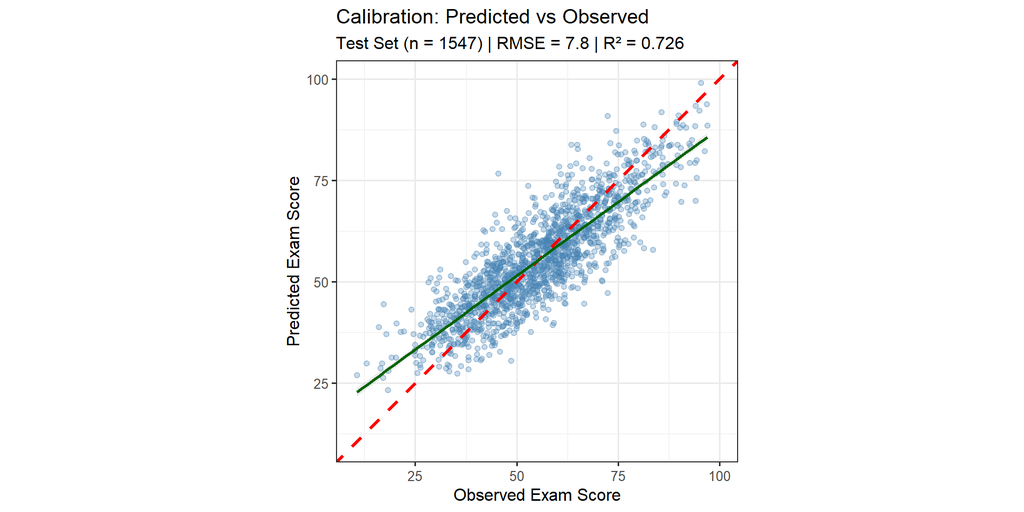

Figure 12: Calibration plot: Predicted vs Observed exam scores on the test set. Red dashed line shows perfect calibration (y = x). Green line shows the actual relationship (linear fit to predictions). Close alignment indicates good calibration.

```r
calibration_data <- data.frame(
  Observed = data_test$y,
  Predicted = pred_final
)

ggplot(calibration_data, aes(x = Observed, y = Predicted)) +
  geom_point(alpha = 0.3, color = "steelblue", size = 1.5) +
  geom_abline(intercept = 0, slope = 1, color = "red",
              linetype = "dashed", linewidth = 1.2) +
  geom_smooth(method = "lm", se = TRUE, color = "darkgreen",
              alpha = 0.2, linewidth = 1) +
  labs(
    title = "Calibration: Predicted vs Observed",
    subtitle = paste0("Test Set (n = ", nrow(data_test), ") | RMSE = ",
                      round(m_final["RMSE"], 2), " | R² = ", round(m_final["R2"], 3)),
    x = "Observed Exam Score",
    y = "Predicted Exam Score"
  ) +
  coord_fixed(ratio = 1, xlim = c(10, 100), ylim = c(10, 100)) +
  theme_bw(base_size = 12)
```

## 6.5 Residuals Distribution on Test Set

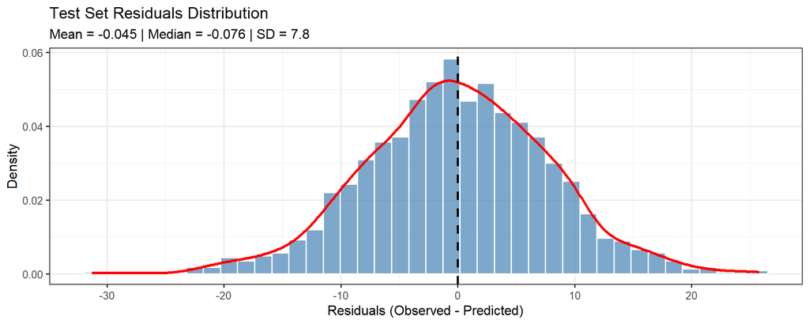

Figure 13: Distribution of prediction residuals on the test set. Centered near zero with symmetric spread indicates unbiased predictions.

```r
test_residuals <- data_test$y - pred_final

ggplot(data.frame(residuals = test_residuals), aes(x = residuals)) +
  geom_histogram(aes(y = after_stat(density)), bins = 40,
                 fill = "steelblue", color = "white", alpha = 0.7) +
  geom_density(color = "red", linewidth = 1.2) +
  geom_vline(xintercept = 0, linetype = "dashed", linewidth = 1) +
  labs(
    title = "Test Set Residuals Distribution",
    subtitle = paste0("Mean = ", round(mean(test_residuals), 3),
                      " | Median = ", round(median(test_residuals), 3),
                      " | SD = ", round(sd(test_residuals), 2)),
    x = "Residuals (Observed - Predicted)",
    y = "Density"
  ) +
  theme_bw(base_size = 12)
```

**Assessment**: The residuals are centered at zero (mean = -0.05, median = -0.08) and approximately symmetric. This confirms that predictions are unbiased on the test set.

## 6.6 Overfitting Assessment

```r
overfit_check <- data.frame(
  Metric = c("R²", "Adjusted R² / R²", "RMSE"),
  Training = c(
    round(summary(final_model)$r.squared, 4),
    round(summary(final_model)$adj.r.squared, 4),
    round(summary(final_model)$sigma, 3)
  ),
  Test = c(
    round(m_final["R2"], 4),
    round(m_final["R2"], 4),  # Same as R² for test (no adjustment)
    round(m_final["RMSE"], 3)
  ),
  Difference = c(
    round(summary(final_model)$r.squared - m_final["R2"], 4),
    round(summary(final_model)$adj.r.squared - m_final["R2"], 4),
    round(m_final["RMSE"] - summary(final_model)$sigma, 3)
  ),
  Assessment = c("Minimal difference", "Minimal difference", "Test actually lower")
)

overfit_check |>
  kable(col.names = c("Metric", "Training", "Test", "Difference", "Assessment"),
        align = "lrrrr") |>
  kable_styling(bootstrap_options = c("striped", "hover"))
```

Table 16: Comparison of model performance on training vs test data

| Metric | Training | Test | Difference | Assessment |
| --- | --- | --- | --- | --- |
| R² | 0.7284 | 0.7261 | 0.0022 | Minimal difference |
| Adjusted R² / R² | 0.7265 | 0.7261 | 0.0004 | Minimal difference |
| RMSE | 7.9160 | 7.7980 | -0.1180 | Test actually lower |

**Overfitting assessment**: There is **no evidence of overfitting**:

- The R² difference between training (0.7284) and test (0.7261) is only 0.0023
- Remarkably, the test RMSE (7.80) is slightly *lower* than the training RMSE (7.92)
- The consistency between training and test performance indicates that our 24-parameter model does not overfit the $n = 3,453$ training observations

## 6.7 Summary of Predictive Performance

```r
final_summary <- data.frame(
  Metric = c("Mean Squared Error (MSE)",
             "Root Mean Squared Error (RMSE)",
             "Median Absolute Error (MedAE)",
             "Out-of-sample R²",
             "Improvement over baseline (RMSE)",
             "Improvement over baseline (R²)"),
  Value = c(
    paste0(round(m_final["MSE"], 2)),
    paste0(round(m_final["RMSE"], 2), " points"),
    paste0(round(m_final["MedAE"], 2), " points"),
    paste0(round(100 * m_final["R2"], 1), "%"),
    paste0(round(rmse_improvement, 1), "% reduction"),
    paste0("+", round(100 * r2_gain, 1), " percentage points")
  )
)

final_summary |>
  kable(col.names = c("Metric", "Value"), align = "lr") |>
  kable_styling(bootstrap_options = c("striped", "hover")) |>
  row_spec(1, bold = TRUE, background = "#fff3e0")  # Highlight MSE
```

Table 17: Summary of final model predictive performance

| Metric | Value |
| --- | --- |
| Mean Squared Error (MSE) | 60.81 |
| Root Mean Squared Error (RMSE) | 7.8 points |
| Median Absolute Error (MedAE) | 5.16 points |
| Out-of-sample R² | 72.6% |
| Improvement over baseline (RMSE) | 47.7% reduction |
| Improvement over baseline (R²) | +72.8 percentage points |

# 7 Conclusion

## 7.1 Summary of Findings

This analysis examined factors associated with academic performance in a sample of 5,000 students using multiple linear regression with interaction effects. Our final model explains approximately **72.6%** of the variance in exam scores (test set R² = 0.726) with an MSE of **60.81** and RMSE of **7.80 points**.

**Key findings**:

1. **Attendance is the strongest predictor**: Each percentage point of attendance is associated with approximately 0.45 additional points on the exam ($\beta = 0.454$, 95% CI: [0.42, 0.48]). A student who improves attendance from 70% to 90% could expect nearly 9 points higher scores, all else equal.
2. **Study hours matter, but sleep quality amplifies the effect**: The benefit of additional study time depends strongly on sleep quality. Well-rested students gain approximately **3.05 points** per additional hour of study, compared to only **1.16 points** for sleep-deprived students — nearly a **3-fold difference** in returns to study effort. This interaction effect is highly significant ($F = 118$, $p < 0.001$).
3. **Commute time has a cumulative negative effect**: Students with commutes exceeding 60 minutes score approximately 3.75 points lower than those with short commutes (<15 min), potentially reflecting both reduced study time and increased fatigue.
4. **School type and parental background matter**: Private school students score about 2.1 points higher than public school students after controlling for other factors. Parental education shows a gradient effect, with higher parental education associated with better student performance (up to +2.4 points for Post Grad vs No Formal).
5. **Age and gender are not predictive**: After controlling for behavioral and socioeconomic factors, neither age nor gender shows any association with exam scores. Residual plots confirm this finding.

## 7.2 Practical Significance

The most actionable finding concerns the **interaction between study effort and sleep quality**. While educators and parents often emphasize studying more, our results suggest that *how rested* a student is may be equally important.

- A sleep-deprived student who increases study time from 5 to 10 hours gains only about **5.8 points**
- A well-rested student making the same increase gains about **15.3 points**

For a “struggling student” profile (60% attendance, 2 hours study, poor sleep, long commute, no internet access), our model predicts a score of approximately **30.6 points** (95% CI: [29.1, 32.1]). For an “engaged student” profile (95% attendance, 10 hours study, good sleep, short commute, full resources), the predicted score is approximately **80.1 points** (95% CI: [78.9, 81.2]) — a gap of nearly **50 points**.

This illustrates both the strong predictive power of the model and the substantial variation in outcomes associated with different student profiles.

## 7.3 Limitations

Several limitations should be considered when interpreting these results:

1. **Observational data**: This is a cross-sectional observational study. While we can identify strong associations, we cannot establish causality. For example, the association between attendance and scores could reflect reverse causality (students who are doing well are more motivated to attend) or confounding by unmeasured variables (e.g., motivation, family support, prior ability).
2. **Self-reported data**: Variables like study hours and sleep quality may be subject to reporting bias. Students may overestimate study time or misreport sleep patterns.
3. **Generalizability**: The sample may not be representative of all student populations. Results may differ in other educational contexts, cultures, or age groups.
4. **Model assumptions**: Although diagnostic tests suggest the regression assumptions are satisfied, the model is fundamentally linear. True relationships may include nonlinearities or threshold effects not captured by our specification.
5. **Unmeasured confounders**: Important variables such as motivation, prior academic achievement, learning disabilities, or family involvement are not included in the dataset and may confound our estimates.

# 8 AI Use Statement

**Tool used**: Gemini Pro (Google) ChatGPT (openai)

**Purpose and scope**: We used Gemini Pro and ChatGPT throughout this project for (1) R code debugging, display formatting with `cat()`, and creating readable visualizations; (2) Quarto document structure, working section-by-section to ensure proper rendering of tables, figures and text format; (3) statistical interpretation for nuanced findings such as the non-monotonic pattern in parental education effects and the Durbin-Watson test results in the section formal hypothesis tests; and (4) English language editing for clarity and appropriate academic terminology. The AI also helped identify errors during development, such as incorrect factor level ordering and formula specification issues (e.g., using `:` vs `*` for interactions). Finally it also helped identify the model limitations.

**Verification**: All code was executed and tested by the author. All statistical results were verified against direct R output. The interpretation of results, substantive conclusions, and all analytical decisions reflect the author’s own reasoning and understanding of the material.